# Modelos de regresión múltiple

Ayudantía 07 · FAGOB 2026

Cristóbal Mejías · Facultad de Gobierno

Métodos Cuantitativos para la Administración Pública

junio de 2026

## ¿Qué veremos hoy?

1. Modelos de regresión múltiple
2. Caso aplicado: CEP 2025
3. Variables categóricas: factores y *dummies*
4. Modelos anidados y tablas
5. Ejercicios aplicados

# Regresión múltiple

## No es lo mismo que varias regresiones simples

El modelo de regresión múltiple estima el efecto de cada predictor **controlando** por los demás. Así se obtiene la contribución propia de cada variable independiente a la variable dependiente.

$$Y = \beta_0 + \beta_1X_1 + \beta_2X_2 + \dots + \beta_kX_k + \epsilon$$

- $\beta_0$: intercepto
- $\beta_1 \dots \beta_k$: coeficientes de cada variable independiente
- $\epsilon$: error

## Interpretación de los coeficientes

- **Coeficiente ($\beta_i$):** cambio esperado en $Y$ por cada unidad de cambio en $X_i$, manteniendo constantes las demás variables.
- **Signo:** dirección de la relación (positiva o negativa).
- **Magnitud:** fuerza de la relación, en las unidades de $Y$.

## Supuestos

1. **Linealidad:** la relación entre las variables es lineal.
2. **Independencia:** los errores son independientes entre sí.
3. **Homocedasticidad:** la varianza de los errores es constante.
4. **Normalidad:** los errores se distribuyen normalmente.

Se pueden revisar todos a la vez con `performance::check_model()`.

# Caso aplicado: CEP 2025

## Paquetes y datos

```r
pacman::p_load(
  tidyverse,      # manipulación de datos
  sjmisc,         # descriptivos (descr)
  sjlabelled,     # etiquetas y valores perdidos (set_na)
  modelsummary,   # tablas y gráficos de modelos
  sjPlot          # tablas de regresión en HTML
)
```

```r
cep <- readRDS(gzcon(url("https://github.com/Cristobal-Mejias-G/metodos-cuantitativos-fagob/raw/main/datos/cep95.rds")))
```

Encuesta CEP N° 95 (octubre 2025), 1217 casos. El procesamiento inicial está en `datos/preparar_cep95.R`.

## Primero: los valores perdidos

En la CEP, **-8 = no sabe** y **-9 = no responde**. Si no los convertimos, `lm()` los trata como valores reales de la escala.

```r
cep <- cep |>
  mutate(across(everything(), haven::zap_labels)) |>   # de haven_labelled a número
  set_na(esc_delincuencia, esc_responsabilidad, esc_ingreso_merito,
         democracia, lider_autoritario, aborto, eutanasia,
         confianza_justicia, confianza_congreso, confianza_gobierno,
         na = c(-8, -9))
```

`pos_pol` queda fuera a propósito: ahí -8 y -9 serán una categoría propia, “Sin posición”.

## Descriptivos

```r
descr(cep, show = c("label", "range", "mean", "sd", "NA.prc", "n")) |>
  knitr::kable(digits = 2)
```

|  | var | label | n | NA.prc | mean | sd | range |
| --- | --- | --- | --- | --- | --- | --- | --- |
| 7 | esc_delincuencia | Preferencia: Garantizar libertades vs. Suprimir libertades para controlar delincuencia | 1167 | 4.11 | 6.49 | 2.90 | 10 (0-10) |
| 9 | esc_responsabilidad | Preferencia: Estado vs. Individuos como responsables del sustento económico | 1196 | 1.73 | 6.06 | 2.96 | 9 (1-10) |
| 8 | esc_ingreso_merito | Preferencia: Igualdad de ingresos vs. Premiar el esfuerzo individual | 1187 | 2.47 | 6.80 | 2.77 | 9 (1-10) |
| 12 | pos_pol | Posición política | 1217 | 0.00 | 2.54 | 6.21 | 19 (-9-10) |
| 13 | sexo | Sexo | 1217 | 0.00 | 1.58 | 0.49 | 1 (1-2) |
| 6 | educacion | Nivel de educación | 1204 | 1.07 | 4.60 | 2.27 | 10 (0-10) |
| 5 | democracia | Preferencia de régimen político: Democracia vs. Autoritarismo vs. Indiferencia | 1160 | 4.68 | 1.80 | 0.85 | 2 (1-3) |
| 11 | lider_autoritario | Apoyo o rechazo a líder fuerte sin congreso ni elecciones | 1140 | 6.33 | 2.89 | 1.10 | 3 (1-4) |
| 1 | aborto | Preferencia sobre el aborto | 1201 | 1.31 | 2.15 | 0.70 | 2 (1-3) |
| 10 | eutanasia | Preferencia sobre la eutanasia | 1186 | 2.55 | 1.86 | 0.63 | 2 (1-3) |
| 4 | confianza_justicia | Confianza en Tribunales de justicia | 1189 | 2.30 | 3.18 | 0.76 | 3 (1-4) |
| 2 | confianza_congreso | Confianza en el Congreso | 1170 | 3.86 | 3.34 | 0.68 | 3 (1-4) |
| 3 | confianza_gobierno | Confianza en el Gobierno | 1197 | 1.64 | 3.14 | 0.86 | 3 (1-4) |

# Variables categóricas: ¿factor o *dummies*?

## Opción 1: como factor

```r
cep <- cep |>
  mutate(pos_pol_rec = case_when(
    pos_pol %in% 1:4  ~ "Izquierda",
    pos_pol %in% 5:6  ~ "Centro",
    pos_pol %in% 7:10 ~ "Derecha",
    pos_pol %in% c(-8, -9) ~ "Sin posición"
  ) |>
    factor(levels = c("Izquierda", "Centro", "Derecha", "Sin posición")))

modelo_factor <- lm(esc_delincuencia ~ pos_pol_rec, data = cep)
```

R crea las *dummies* automáticamente. La **primera categoría** de `levels` (Izquierda) queda como referencia.

## Opción 2: *dummies* a mano

```r
cep <- cep |>
  mutate(
    pol_centro       = if_else(pos_pol %in% 5:6, 1, 0),
    pol_derecha      = if_else(pos_pol %in% 7:10, 1, 0),
    pol_sin_posicion = if_else(pos_pol %in% c(-8, -9), 1, 0)
  )

modelo_dummies <- lm(esc_delincuencia ~ pol_centro + pol_derecha + pol_sin_posicion,
                     data = cep)
```

La categoría que **no** incluimos (Izquierda) es la referencia. Si incluyéramos las cuatro, el modelo no podría estimarse.

## Ambos caminos dan lo mismo

```r
modelsummary(
  list("Factor" = modelo_factor,
       "Dummies" = modelo_dummies),
  estimate  = "{estimate}{stars} ({std.error})",
  statistic = NULL,
  gof_map = c("nobs", "r.squared")
)
```

|  | Factor | Dummies |
| --- | --- | --- |
| (Intercept) | 5.162*** (0.188) | 5.162*** (0.188) |
| pos_pol_recCentro | 1.147*** (0.231) |  |
| pos_pol_recDerecha | 2.354*** (0.250) |  |
| pos_pol_recSin posición | 1.675*** (0.262) |  |
| pol_centro |  | 1.147*** (0.231) |
| pol_derecha |  | 2.354*** (0.250) |
| pol_sin_posicion |  | 1.675*** (0.262) |
| Num.Obs. | 1167 | 1167 |
| R2 | 0.075 | 0.075 |

## Cambiar la categoría de referencia

Con un factor basta con `fct_relevel()`:

```r
cep |>
  mutate(pos_pol_rec = fct_relevel(pos_pol_rec,
                                   "Centro")) |>
  lm(esc_delincuencia ~ pos_pol_rec,
     data = _) |>
  modelsummary(estimate  = "{estimate}{stars} ({std.error})",
               statistic = NULL,
               gof_map = c("nobs", "r.squared"))
```

|  | (1) |
| --- | --- |
| (Intercept) | 6.309*** (0.135) |
| pos_pol_recIzquierda | -1.147*** (0.231) |
| pos_pol_recDerecha | 1.207*** (0.214) |
| pos_pol_recSin posición | 0.528* (0.228) |
| Num.Obs. | 1167 |
| R2 | 0.075 |

`data = _` indica dónde entra el resultado del pipe cuando no es el primer argumento.

# Recodificación del resto de variables

## Educación, régimen y líder autoritario

```r
cep <- cep |>
  mutate(
    educ_rec = case_when(
      educacion %in% 0:4  ~ "Media completa o inferior",
      educacion %in% 5:7  ~ "Universitaria incompleta o técnica",
      educacion %in% 8:10 ~ "Universitaria completa o superior"
    ) |>
      factor(levels = c("Media completa o inferior",
                        "Universitaria incompleta o técnica",
                        "Universitaria completa o superior")),
    pref_dem_rec = factor(democracia, levels = 1:3,
                          labels = c("Democracia", "Autoritarismo", "Indiferencia")),
    apoyo_lider_autoritario = if_else(lider_autoritario %in% 1:2, 1, 0)
  )
```

## Aborto, eutanasia y confianza en el Estado

```r
cep <- cep |>
  mutate(
    aborto_rec = factor(aborto, levels = 1:3,
                        labels = c("Siempre prohibido", "Casos especiales", "Opción libre")),
    eutanasia_rec = factor(eutanasia, levels = c(3, 1, 2),
                           labels = c("Nunca permitida", "Siempre permitida", "Casos especiales")),
    # Confianza: original 1 = mucha ... 4 = nada. Invertimos para que más = más confianza
    across(starts_with("confianza"), \(x) 5 - x, .names = "{.col}_inv"),
    esc_confianza_estado = confianza_justicia_inv + confianza_congreso_inv +
      confianza_gobierno_inv - 2   # escala de 1 a 10
  )
```

`5 - x` invierte una escala de 1 a 4 en una sola operación. `across()` la aplica a todas las variables que empiezan con “confianza”.

# Modelos anidados

## Estrategia

Se parte de un modelo simple y se agregan predictores de forma progresiva. Así evaluamos:

- Cómo cambian los coeficientes al agregar controles
- Si las nuevas variables mejoran la capacidad explicativa ($R^2$ ajustado)
- Si el efecto de una variable es robusto o desaparece al controlar por otras

## Misma muestra para todos los modelos

Para comparar modelos anidados, todos deben usar **los mismos casos**:

```r
cep_m <- cep |>
  drop_na(esc_delincuencia, pos_pol_rec, educ_rec,
          apoyo_lider_autoritario, pref_dem_rec)
```

```r
m1 <- lm(esc_delincuencia ~ pos_pol_rec, data = cep_m)
m2 <- lm(esc_delincuencia ~ pos_pol_rec + educ_rec, data = cep_m)
m3 <- lm(esc_delincuencia ~ pos_pol_rec + educ_rec +
           apoyo_lider_autoritario + pref_dem_rec, data = cep_m)
```

`drop_na()` solo sobre las variables del modelo más completo. Con `na.omit()` sobre toda la base perderíamos casos por variables que no usamos.

## Comparación de los tres modelos

```r
modelsummary(
  list("M1: Pos. política" = m1, "M2: + Educación" = m2, "M3: + Actitudes" = m3),
  estimate    = "{estimate}{stars} ({std.error})",
  statistic   = NULL,
  gof_map     = c("nobs", "r.squared", "adj.r.squared"),
  coef_rename = \(x) x |>
    str_remove("pos_pol_rec|educ_rec|pref_dem_rec") |>
    str_replace("apoyo_lider_autoritario", "Apoyo líder autoritario")
)
```

|  | M1: Pos. política | M2: + Educación | M3: + Actitudes |
| --- | --- | --- | --- |
| (Intercept) | 5.083*** (0.188) | 5.371*** (0.209) | 5.048*** (0.221) |
| Centro | 1.195*** (0.232) | 1.071*** (0.234) | 0.867*** (0.237) |
| Derecha | 2.412*** (0.251) | 2.292*** (0.252) | 2.099*** (0.256) |
| Sin posición | 1.729*** (0.267) | 1.533*** (0.271) | 1.346*** (0.273) |
| Universitaria incompleta o técnica |  | -0.159 (0.203) | -0.043 (0.205) |
| Universitaria completa o superior |  | -0.826*** (0.232) | -0.613** (0.236) |
| Apoyo líder autoritario |  |  | 0.178 (0.184) |
| Autoritarismo |  |  | 0.596** (0.215) |
| Indiferencia |  |  | 0.783*** (0.212) |
| Num.Obs. | 1117 | 1117 | 1117 |
| R2 | 0.081 | 0.091 | 0.108 |
| R2 Adj. | 0.078 | 0.087 | 0.101 |

## Los coeficientes en un gráfico

```r
modelplot(list("M1" = m1, "M2" = m2, "M3" = m3),
          coef_omit = "Intercept") +
  geom_vline(xintercept = 0, linetype = "dashed")
```

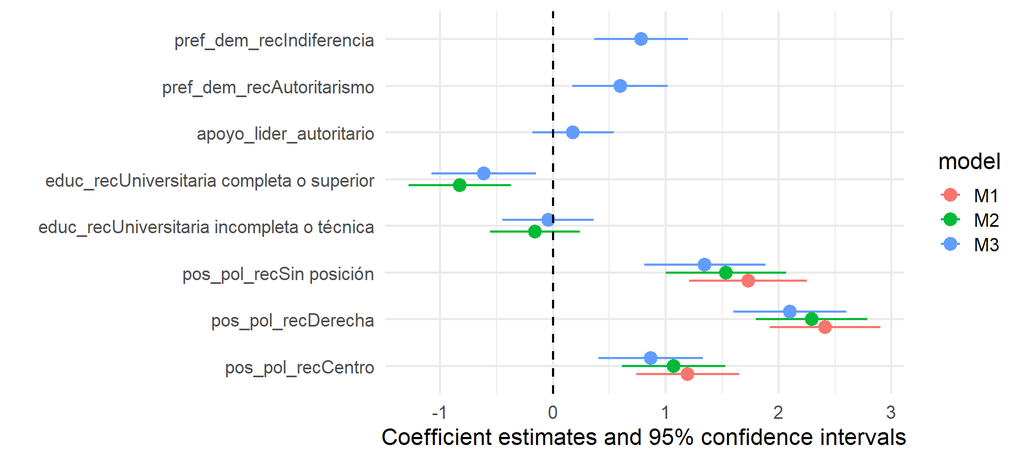

Si el intervalo cruza la línea punteada (0), el coeficiente no es significativo al 95%.

## Lectura e interpretación

- En M1, ubicarse a la derecha se asocia positivamente con la preferencia por suprimir libertades, en relación con quienes se ubican a la izquierda.
- Al agregar educación (M2), el efecto de la posición política se mantiene, y un mayor nivel educativo tiende a asociarse negativamente con la supresión de libertades.
- En M3, la preferencia por el autoritarismo y la indiferencia frente a la democracia tienen efectos positivos y significativos.
- El $R^2$ ajustado aumenta progresivamente: 0.078 (M1), 0.087 (M2) y 0.101 (M3).

## Exportar tablas

```r
# A Word, para un informe
modelsummary(list(m1, m2, m3), stars = TRUE, output = "output/modelos.docx")

# Tabla HTML con sjPlot
tab_model(m1, m2, m3, show.ci = FALSE, dv.labels = c("M1", "M2", "M3"))
```

# Ejercicios aplicados

## Ejercicio 1: conceptual

1. ¿Cuál es la diferencia entre estimar varias regresiones simples por separado y un modelo de regresión múltiple? ¿Por qué importa para interpretar los coeficientes?
2. ¿Qué significa que un coeficiente sea significativo pero pequeño? ¿Y al revés?
3. ¿Qué información adicional entrega el $R^2$ ajustado respecto del $R^2$?
4. ¿Por qué hay que definir una categoría de referencia? ¿Qué ocurre si se incluyen todas las categorías como *dummies*?

## Ejercicio 2: responsabilidad económica

**Variable dependiente:** `esc_responsabilidad` (1 = el Estado es responsable del sustento económico; 10 = las personas son responsables).

1. Estima tres modelos anidados:
   - **M1:** posición política (`pos_pol_rec`, ref. = Izquierda)
   - **M2:** M1 + educación (`educ_rec`, ref. = Media completa o inferior)
   - **M3:** M2 + aborto (`aborto_rec`, ref. = Siempre prohibido) + eutanasia (`eutanasia_rec`, ref. = Nunca permitida)
2. Compáralos con `modelsummary()` y `modelplot()`.
3. ¿Cómo se relacionan las actitudes sobre aborto y eutanasia con la preferencia por responsabilidad individual? ¿Se mantiene el efecto de la posición política?

## Ejercicio 3: mérito e igualdad de ingresos

**Variable dependiente:** `esc_ingreso_merito` (1 = ingresos más iguales; 10 = premiar el esfuerzo individual).

1. Estima tres modelos anidados:
   - **M1:** posición política (ref. = Izquierda)
   - **M2:** M1 + educación + preferencia de régimen (`pref_dem_rec`, ref. = Democracia)
   - **M3:** M2 + aborto + eutanasia
2. Compáralos con `modelsummary()`.
3. ¿Es razonable esperar que las actitudes sobre aborto y eutanasia predigan preferencias redistributivas?

# Nos vemos en la próxima ayudantía. ¡Gracias por su atención!